# Country Code

Will Moscato, Franco Salinas, Juthi Dewan

```r
library(countrycode)
library(dplyr)
```

```r
library("ggplot2")
library("sf")
library("rnaturalearth")
library("rnaturalearthdata")
library(rgeos)
```

## Origin and Destination

##### The countrycode package has two main features that we’ll be explaning today: countrycode and countryname. What this package generally does is it takes in a country name or country code and converts it into a different language or country code of our choice. This package in itself is pretty simple and can be used very easily to clean up datasets in the pre-processing step. It’s a great way to standardize country names and codes if we are using several different datasets and can be great in making labels when mapping and making other visualizations. Although there was a group who has done geom_sf in the past, I will show some examples of using countrycode with geom_sf down below.

##### For this package, the most important thing is the origin and desitination input for the country names and codes. Given below is a list of details for both origins and destinations along with a description of what they are:

• ccTLD: IANA country code top-level domain

• country.name: country name (English)

• country.name.de: country name (German)

• cowc: Correlates of War character

• cown: Correlates of War numeric

• dhs: Demographic and Health Surveys Program

• ecb: European Central Bank

• eurostat: Eurostat

• fao: Food and Agriculture Organization of the United Nations numerical code

• fips: FIPS 10-4 (Federal Information Processing Standard)

• gaul: Global Administrative Unit Layers

• genc2c: GENC 2-letter code

• genc3c: GENC 3-letter code

• genc3n: GENC numeric code

• gwc: Gleditsch & Ward character

• gwn: Gleditsch & Ward numeric

• imf: International Monetary Fund

• ioc: International Olympic Committee

• iso2c: ISO-2 character

• iso3c: ISO-3 character

• iso3n: ISO-3 numeric

• p4n: Polity IV numeric country code

• p4c: Polity IV character country code

• un: United Nations M49 numeric codes

• unicode.symbol: Region subtag (often displayed as emoji flag)

• unpd: United Nations Procurement Division

• vdem: Varieties of Democracy (V-Dem version 8, April 2018)

• wb: World Bank (very similar but not identical to iso3c)

• wvs: World Values Survey numeric code

##### In addition to these origins and destinations, there are more destinations.Destinations are the output expected from the country names. Look at the codelist to see all of the different destinations that a country code or name may be converted to.

```r
codelist %>%
  head(10)
```

| ar5 | cctld | continent | country.name.de | country.name.de.regex | country.name.en | country.name.en.regex | cow.name | cowc | cown | currency | dhs | ecb | eu28 | eurocontrol_pru | eurocontrol_statfor | eurostat | fao | fips | gaul | genc2c | genc3c | genc3n | gwc | gwn | icao.region | imf | ioc | iso.name.en | iso.name.fr | … |
| --- | --- | --- | --- | --- | --- | --- | --- | --- | --- | --- | --- | --- | --- | --- | --- | --- | --- | --- | --- | --- | --- | --- | --- | --- | --- | --- | --- | --- | --- | --- |
| ASIA | .af | Asia | Afghanistan | afghan | Afghanistan | afghan | Afghanistan | AFG | 700 | Afghani | AF | AF | NA | Asia | Asia/Pacific | AF | 2 | AF | 1 | AF | AFG | 004 | AFG | 700 | ASIAPAC | 512 | AFG | Afghanistan | Afghanistan (l') | … |
| OECD1990 | .ax | Europe | Aland Islands | åland | Åland Islands | ^[å\|a]land | NA | NA | NA | Euro | NA | NA | NA | Eurocontrol | ESRA North-West | NA | NA | NA | NA | NA | NA | NA | NA | NA | NA | NA | NA | Åland Islands | Åland(les Îles) | … |
| EIT | .al | Europe | Albanien | albanien | Albania | albania | Albania | ALB | 339 | Lek | AL | AL | NA | Eurocontrol | ESRA East | AL | 3 | AL | 3 | AL | ALB | 008 | ALB | 339 | EUR | 914 | ALB | Albania | Albanie (l') | … |
| MAF | .dz | Africa | Algerien | algerien | Algeria | algeria | Algeria | ALG | 615 | Algerian Dinar | NA | DZ | NA | Africa | North-Africa | DZ | 4 | AG | 4 | DZ | DZA | 012 | ALG | 615 | EUR | 612 | ALG | Algeria | Algérie (l') | … |
| ASIA | .as | Oceania | Amerikanisch-Samoa | ^(?=.*amerik).*samoa | American Samoa | ^(?=.*americ).*samoa | NA | NA | NA | US Dollar | NA | AS | NA | Asia | Asia/Pacific | AS | 5 | AQ | 5 | AS | ASM | 016 | NA | NA | NA | 859 | ASA | American Samoa | Samoa américaines (les) | … |
| OECD1990 | .ad | Europe | Andorra | andorra | Andorra | andorra | Andorra | AND | 232 | Euro | NA | AD | NA | NA | NA | AD | 6 | AN | 7 | AD | AND | 020 | NA | NA | NA | NA | AND | Andorra | Andorre (l') | … |
| MAF | .ao | Africa | Angola | angola | Angola | angola | Angola | ANG | 540 | Kwanza | AO | AO | NA | Africa | Southern-Africa | AO | 7 | AO | 8 | AO | AGO | 024 | ANG | 540 | AFI | 614 | ANG | Angola | Angola (l') | … |
| LAM | .ai | Americas | Anguilla | anguill?a | Anguilla | anguill?a | NA | NA | NA | East Caribbean Dollar | NA | AI | NA | Southern America | Mid-Atlantic | AI | 258 | AV | 9 | AI | AIA | 660 | NA | NA | NA | 312 | NA | Anguilla | Anguilla | … |
| LAM | .aq | NA | Antarktis | antarktis | Antarctica | antarctica | NA | NA | NA | NA | NA | AQ | NA | Asia | Asia/Pacific | AQ | 30 | AY | 10 | AQ | ATA | 010 | NA | NA | NA | NA | NA | Antarctica | Antarctique (l') | … |
| LAM | .ag | Americas | Antigua und Barbuda | antigua | Antigua & Barbuda | antigua | Antigua & Barbuda | AAB | 58 | East Caribbean Dollar | NA | AG | NA | Southern America | Mid-Atlantic | AG | 8 | AC | 11 | AG | ATG | 028 | NA | NA | CARSAM | 311 | ANT | Antigua and Barbuda | Antigua-et-Barbuda | … |

##### The package also includes a panel of country-year observations with different codes.

```r
codelist_panel %>%
  head(10)
```

| country.name.en | year | ar5 | cctld | continent | country.name.de | country.name.de.regex | country.name.en.regex | cowc | cown | currency | dhs | ecb | eu28 | eurocontrol_pru | eurocontrol_statfor | eurostat | fao | fips | gaul | genc2c | genc3c | genc3n | gwc | gwn | icao.region | imf | ioc | iso2c | iso3c | … |
| --- | --- | --- | --- | --- | --- | --- | --- | --- | --- | --- | --- | --- | --- | --- | --- | --- | --- | --- | --- | --- | --- | --- | --- | --- | --- | --- | --- | --- | --- | --- |
| Afghanistan | 1789 | ASIA | .af | Asia | Afghanistan | afghan | afghan | NA | NA | Afghani | AF | AF | NA | Asia | Asia/Pacific | AF | 2 | AF | 1 | AF | AFG | 004 | AFG | 700 | ASIAPAC | 512 | AFG | AF | AFG | … |
| Afghanistan | 1790 | ASIA | .af | Asia | Afghanistan | afghan | afghan | NA | NA | Afghani | AF | AF | NA | Asia | Asia/Pacific | AF | 2 | AF | 1 | AF | AFG | 004 | AFG | 700 | ASIAPAC | 512 | AFG | AF | AFG | … |
| Afghanistan | 1791 | ASIA | .af | Asia | Afghanistan | afghan | afghan | NA | NA | Afghani | AF | AF | NA | Asia | Asia/Pacific | AF | 2 | AF | 1 | AF | AFG | 004 | AFG | 700 | ASIAPAC | 512 | AFG | AF | AFG | … |
| Afghanistan | 1792 | ASIA | .af | Asia | Afghanistan | afghan | afghan | NA | NA | Afghani | AF | AF | NA | Asia | Asia/Pacific | AF | 2 | AF | 1 | AF | AFG | 004 | AFG | 700 | ASIAPAC | 512 | AFG | AF | AFG | … |
| Afghanistan | 1793 | ASIA | .af | Asia | Afghanistan | afghan | afghan | NA | NA | Afghani | AF | AF | NA | Asia | Asia/Pacific | AF | 2 | AF | 1 | AF | AFG | 004 | AFG | 700 | ASIAPAC | 512 | AFG | AF | AFG | … |
| Afghanistan | 1794 | ASIA | .af | Asia | Afghanistan | afghan | afghan | NA | NA | Afghani | AF | AF | NA | Asia | Asia/Pacific | AF | 2 | AF | 1 | AF | AFG | 004 | AFG | 700 | ASIAPAC | 512 | AFG | AF | AFG | … |
| Afghanistan | 1795 | ASIA | .af | Asia | Afghanistan | afghan | afghan | NA | NA | Afghani | AF | AF | NA | Asia | Asia/Pacific | AF | 2 | AF | 1 | AF | AFG | 004 | AFG | 700 | ASIAPAC | 512 | AFG | AF | AFG | … |
| Afghanistan | 1796 | ASIA | .af | Asia | Afghanistan | afghan | afghan | NA | NA | Afghani | AF | AF | NA | Asia | Asia/Pacific | AF | 2 | AF | 1 | AF | AFG | 004 | AFG | 700 | ASIAPAC | 512 | AFG | AF | AFG | … |
| Afghanistan | 1797 | ASIA | .af | Asia | Afghanistan | afghan | afghan | NA | NA | Afghani | AF | AF | NA | Asia | Asia/Pacific | AF | 2 | AF | 1 | AF | AFG | 004 | AFG | 700 | ASIAPAC | 512 | AFG | AF | AFG | … |
| Afghanistan | 1798 | ASIA | .af | Asia | Afghanistan | afghan | afghan | NA | NA | Afghani | AF | AF | NA | Asia | Asia/Pacific | AF | 2 | AF | 1 | AF | AFG | 004 | AFG | 700 | ASIAPAC | 512 | AFG | AF | AFG | … |

## Country Code:

##### countrycode can take in both country code and country name. What it does is, it converts either the country code or country name to whatever destination we want to convert it to. For countrycode, the origin and destination have to be put in and having to identify the origin (the code associated with the given data) is the hardest part.There are around 30 different origins and destinations for the type of countrynames and countrycodes.

###### The usage of the countrycode function is as follows:

countrycode( sourcevar, origin, destination, warn = TRUE, nomatch = NA, custom_dict = NULL, custom_match = NULL, origin_regex = FALSE )

**Here are some examples of things you can change codes or names into:**

```r
countrycode("USA", "iso3c", "country.name")
```

```
## [1] "United States"
```

```r
#countrycode(source)
```

```r
countrycode("USA", "iso3c", "currency")
```

```
## [1] "US Dollar"
```

```r
countrycode("United States", "country.name", "iso2c")
```

```
## [1] "US"
```

```r
countrycode("United States", "country.name", "un.name.zh")
```

```
## [1] "美利坚合众国"
```

**You can also create your own/ download custom dictionaries for things that are not included in the generic countrycode dictionary.**

```r
cd <- 'https://bit.ly/2ToSrFv'
cd <- read.csv(cd)
countrycode(c('AL', 'AK'), 'abbreviation', 'state',
custom_dict = cd)
```

```
## [1] "Alabama" "Alaska"
```

```r
countrycode(c('Alabama', 'North Dakota'), 'state.regex', 'abbreviation',
custom_dict = cd, origin_regex = TRUE)
```

```
## [1] "AL" "ND"
```

**If your data has a name that isn’t one of the recognized inputs or you want a custom output, you can use custom_match.**

```r
countrycode(c('United States', 'California'), 'country.name', 'iso3c',
custom_match = c('California' = 'CA'))
```

```
## [1] "USA" "CA"
```

**If you don’t know what type of origin you are working with you can use the guess_field function.**

```r
guess_field("United States of America")
```

|  | code | percent_of_unique_matched |
| --- | --- | --- |
| cow.name | cow.name | 100 |
| un.name.en | un.name.en | 100 |
| vdem.name | vdem.name | 100 |

## Country Name:

##### Countryname can only take in names of countries and not codes. But the convenient thing about countryname is that there is no need to input an origin. For countryname, the only input is the data$country_name and the destination / type of country name or code we want to convert the country name to. It detects variations of country names in many languages and then it applies the ‘countrycodes’ English regexes for the remaining cases.

###### The usage of the countryname function is as follows:

countrycode( sourcevar, destination, warn = FALSE, )

**Here are some examples of things you can change names into:**

```r
#Here we find the continent for each of the countries in the data set
data <- read.csv("gdp.csv")
countryname(data$Economy, destination = "continent", warn = FALSE) %>%
  head(10)
```

```
##  [1] "Asia"     "Americas" "Asia"     "Asia"     "Europe"   "Europe"
##  [7] "Americas" "Asia"     "Europe"   "Europe"
```

```r
#Here we translate all of the country names into Bangla
countryname(data$Economy, destination = "cldr.name.bn", warn = FALSE) %>%
  head(10)
```

```
##  [1] "চীন"             "মার্কিন যুক্তরাষ্ট্র" "ভারত"            "জাপান"
##  [5] "জার্মানি"         "রাশিয়া"          "ব্রাজিল"          "ইন্দোনেশিয়া"
##  [9] "যুক্তরাজ্য"         "ফ্রান্স"
```

```r
#Here we translate all of the country names into Spanish
countryname(data$Economy, destination = "cldr.name.es", warn = FALSE) %>%
  head(10)
```

```
##  [1] "China"          "Estados Unidos" "India"          "Japón"
##  [5] "Alemania"       "Rusia"          "Brasil"         "Indonesia"
##  [9] "Reino Unido"    "Francia"
```

```r
#Here we translate all of the country names into Hebrew
countryname(data$Economy, destination = "cldr.name.he", warn = FALSE) %>%
  head(10)
```

```
##  [1] "סין"         "ארצות הברית" "הודו"        "יפן"         "גרמניה"
##  [6] "רוסיה"       "ברזיל"       "אינדונזיה"   "בריטניה"     "צרפת"
```

```r
#Here we find the currencies for the countries in the data set
countryname(data$Economy, destination = "currency", warn = FALSE) %>%
  head(10)
```

```
##  [1] "Yuan Renminbi"  "US Dollar"      "Indian Rupee"   "Yen"
##  [5] "Euro"           "Russian Ruble"  "Brazilian Real" "Rupiah"
##  [9] "Pound Sterling" "Euro"
```

## Mapping: countrycode + geom_sf

##### We’ve learned about the geom_sf package in this class before, so I’m only going to briefly touch on it this time. The package comes with data for countries around the world with their coordinates, continents, code names, etc. so we will be using the world data from the geom_sf package.

```r
#finding coordinates for every country in the world dataset
world <- ne_countries(scale = "medium", returnclass = "sf")
coordinates <- cbind(world, st_coordinates(st_centroid(world$geometry)))
coordinates <-
  coordinates %>%
  select(name,sovereignt, type, X,Y)
```

##### World map with country labels in Arabic

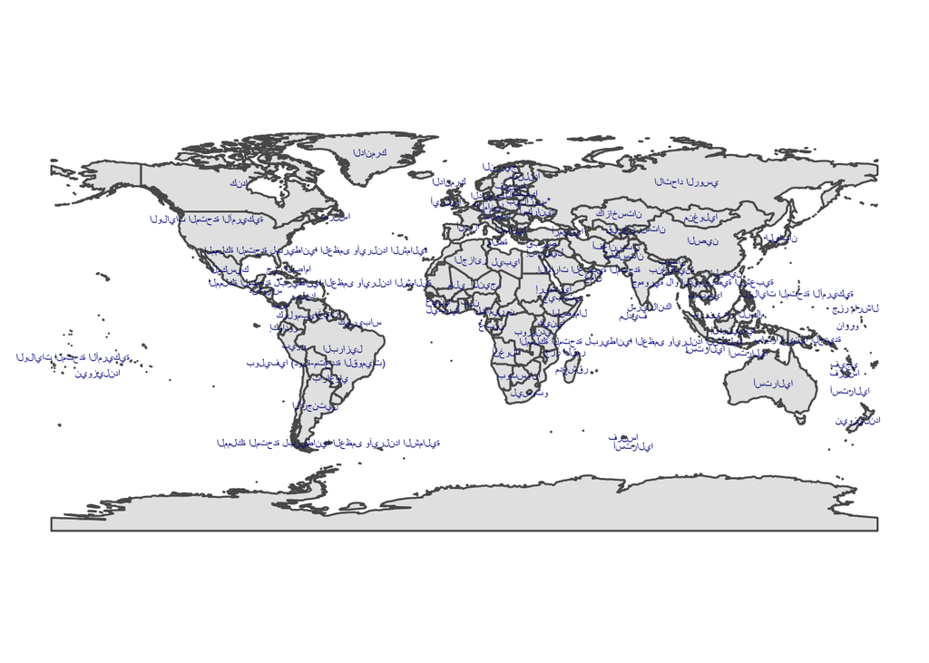

```r
#using countrycode on coordinates data
Arabic <-
  mutate(coordinates) %>%
  mutate(arabic = countrycode(sovereignt, origin = 'country.name', destination = 'un.name.ar'))

#world map with Arabic labels
ggplot(data = world) +
    geom_sf() +
    geom_text(data=Arabic ,aes(X, Y, label=arabic),
    color = "darkblue", check_overlap = TRUE, size=2)+
    labs(x = NULL,
         y = NULL)+
    theme(panel.background = element_blank())
```

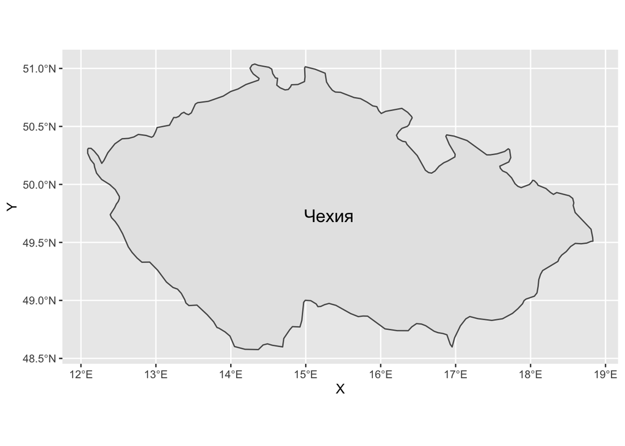

```r
#creating a dataset with the coordinates and currency for Bangladesh
bangladesh <-
  bangladesh <- coordinates[world$name == 'Bangladesh',] %>%
  mutate(label = countryname(name, destination = 'currency'))

#creating a dataset with the coordinates and name in Russian for Czech Republic
czech <-
  coordinates[coordinates$name == 'Czech Rep.',] %>%
  mutate(label = countryname(name, destination = 'cldr.name.ru'))

#creating a dataset with the coordinates and currency for Nepal
nepal <-
  coordinates[coordinates$name == 'Nepal',] %>%
  mutate(label = countryname(name, destination = 'currency'))

#creating a dataset with the coordinates and currency for Myanmar
myanmar <-
  coordinates[coordinates$name == 'Myanmar',] %>%
  mutate(label = countryname(name, destination = 'currency'))

#creating a dataset with the coordinates and currency for India
india <-
  coordinates[coordinates$name == 'India',] %>%
  mutate(label = countryname(name, destination = 'currency'))


#creating a dataset with the coordinates and currency for Sri Lanka
srilanka <-
  coordinates[coordinates$name == 'Sri Lanka',] %>%
  mutate(label = countryname(name, destination = 'currency'))

#mapping Czech Republic with Russian name label
ggplot() +
  geom_sf(data = czech) +
  geom_text(data=czech ,aes(X, Y, label=label),
            check_overlap = TRUE, size=5)
```

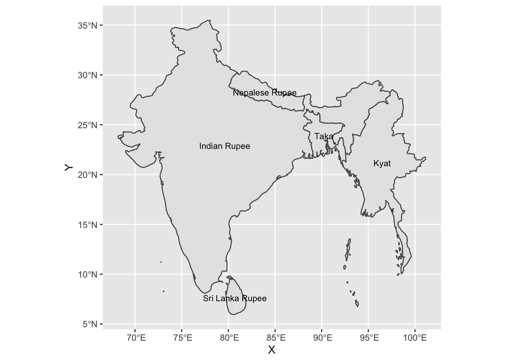

```r
#mapping Bangladesh, Nepal, India, Sri Lanka and Myanmar with currencies as label
ggplot() +
  geom_sf(data = bangladesh) +
  geom_sf(data = nepal) +
  geom_sf(data = india) +
  geom_sf(data = srilanka) +
  geom_sf(data = myanmar) +
  geom_text(data=bangladesh ,aes(X, Y, label=label), size=3) +
  geom_text(data=nepal ,aes(X, Y, label=label), size=3) +
  geom_text(data=india ,aes(X, Y, label=label), size=3) +
  geom_text(data=myanmar ,aes(X, Y, label=label), size=3) +
  geom_text(data=srilanka ,aes(X, Y, label=label), size=3)
```

## Exercises:

##### Question 1: Convert the name of a country of choice into five different languages of your choice. Use the world dataset and use countryname. You can also use ‘codelist’ to look at different destinations. (Remove eval=FALSE)

```r
#remove eval=FALSE before running
question1 <-
  world %>%
  filter(name == '???')

#Repeat the code down below for 4 other languages.
countryname(question1$name, '???')
```

##### Question 2: Find the ‘region’ name and code for the top 30 countries. Use ‘countrycode’ for this.

```r
#remove eval=FALSE before running
question2 <-
  world %>%
  head(30)

countrycode(question2$name, origin = '???', destination = '???')
```

##### Question 3: Use the guess_field() function to find the closest match of the origin of the adm0_a3 column in the world dataset.

##### Question 4: Draw a map with 5 countries with different labels using geom_sf, geom_text and countryname (you have complete freedom over what countries you want to do)

```r
#remove eval=FALSE before running
question4 <-
  coordinates[world$name == ???,] %>%
  mutate(label = countryname(name, destination = '???'))

ggplot() +
  geom_sf(data = ???) +
  geom_text(data=??? ,aes(X, Y, label=???), size=???) +
```

##### Question 5: Draw a map that has each country named after the continent it belongs to and colored by their continent. Make sure your map looks like an actual map (not grids, not axis, add a title, a caption, etc.)